# Model Selection and Assessment - Theory

```python
from IPython.display import Image
```

## Model Selection and Assessment - Theory

Three primary methods:

- (Traditional) Train-Test
- Train-Validation-Test
- k-Fold Cross-Validation

If the dataset is small for its domain, use the traditional approach.

If the dataset is large for its domain, use k-Fold cross-validation.

If the size of the dataset is in the middle for its domain, use train-validation-test.

## (Traditional) Train-Test

Suppose we have $m$ candidate models:

1. Split the data into training data and test data
   1. Generally, training data is ~75% of the data and test data is the remaining 25%
2. Fit each candidate model on the training data and compute the appropriate performance measure (e.x. $R_{adj}^2$ for linear regression)
3. Select the model with the best performance measure
4. Run the selected model on the test data and assess the appropriate out-of-sample performance measure (e.x. $MSE$ for linear regression)

### An aside: what is out-of-sample?

- In-sample refers to observed data, which is used for training models.
- Out-of-sample refers to unobserved data, which we test the training model on.

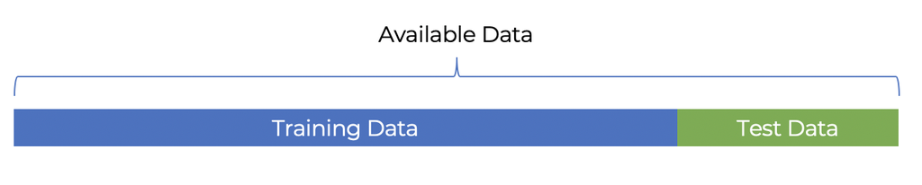

```python
Image("img/train_test.png")
```

Here, the test data is **out-of-sample**.

## Train-Validation-Test

Suppose we have $m$ candidate models:

1. Split the data into training and test data
   1. Generally, training data is ~75% of the data and the test data is the remaining 25%
2. Set aside (generally) $\frac{1}{3}$ of the training data as validation data (25% of the the total data)
   1. So, we will only be "training" on 50% of the total data in this case
3. Fit the candidate models on the remaining $\frac{2}{3}$ training data
4. Compute the appropriate out-of-sample performance measure on the validation data
5. Select the model with the best performance
6. Retrain the selected the model on the entire training dataset (75% of the total data -- that's the combined training and validation data)
7. Run the selected model on the test data (last 25%) and assess the performance

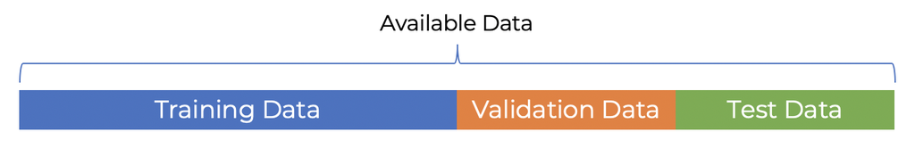

```python
Image("img/train_validation_test.png")
```

Here, first the validation data is **out-of-sample**. After retraining with the entire training dataset (training data + validation data), the test data is the out-of-sample data we test on.

## k-Fold Cross Validation

Suppose we have $m$ candidate models:

1. Randomly divide the training data into $k$ folds of equal size
2. For each candidate model we do the following:
   1. For each fold $j=1,...,k$
      1. Fit the model on all the training data, excluding fold $j$
      2. Compute the appropriate out-of-sample performance measure of the model on fold $j$
   2. Use the average of each out-of-sample performance measure to estimate the performance of the model
3. Select the model with the best estimated performance
4. Retrain the selected model on all of the training data
5. Assess the performance on the test data

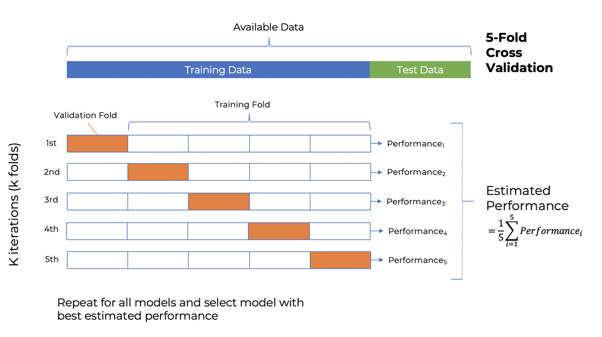

```python
Image("img/k-fold_cv.png")
```

Generally this works best for $k=5$ or $k=10$. No one really knows why (yes, I am also very unhappy with that answer).

### Bias-Variance Tradeoff in Selecting $k$

- Large k - less bias (good), but more variance (bad)
- Small k - more bias (bad), but less variance (good)

This is because the larger $k$ is, the more overlap there will be between datasets. This leads to an increased risk of overfitting.

## Leave-One-Out Cross Validation (LOOCV)

This is the most extreme form of cross validation where $k = n$, where n is the number of data points in the set. This form of cross-validation is approximately unbiased, but has very high variance (remember the tradeoff!). It is computationally inexpensive for:

- Linear Regression
- Nearest-Neighbour classifiers
- Most kernel methods

**LOOCV is useful if you want to run the cross-validation method for a small dataset or if you want an unbiased model.**

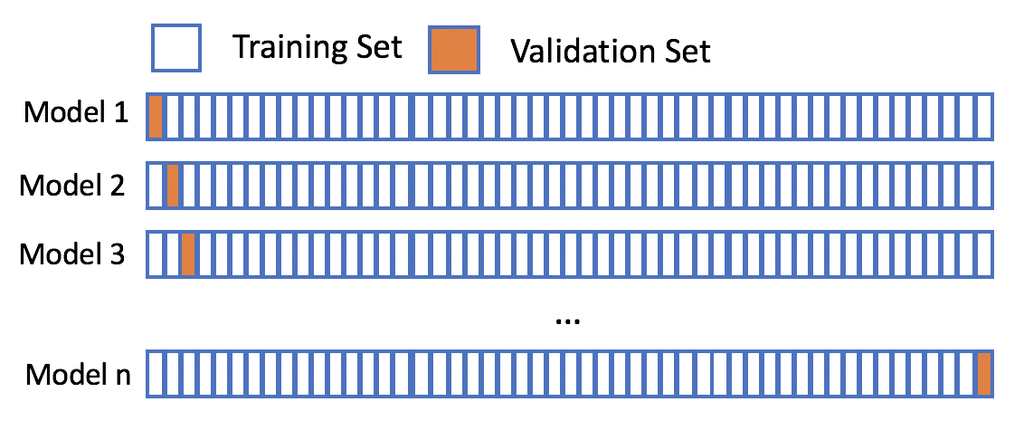

```python
Image('img/loocv.png')
```

Source: DataCamp

The above is a visualization of leave-one-out cross-validation.

## Stratified Cross-Validation

This is a variation of k-fold cross validation where you force each fold to have at least $i$ instances of each class, so that no class is over or under-represented within a fold. This is particularly useful when the target variable is unbalanced.

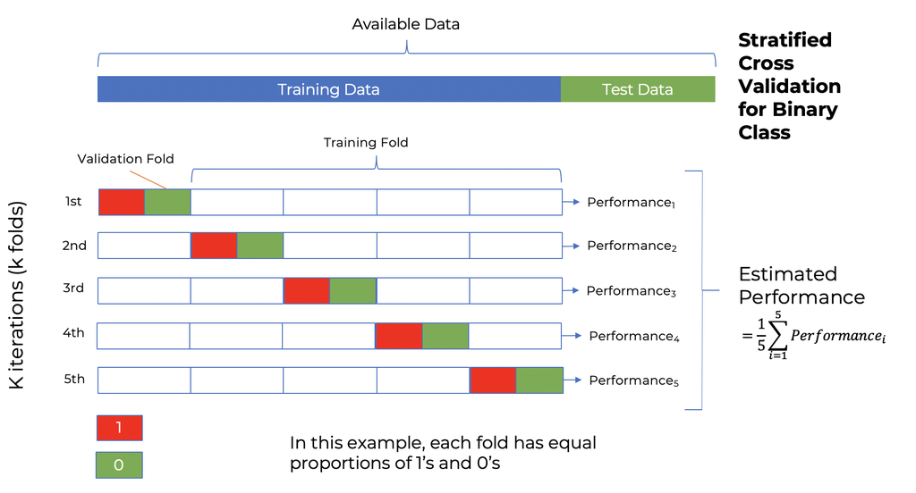

```python
Image('img/stratified_cv.png')
```

## Time Series Cross-Validation

The standard k-fold cross validation procedure does not work for time series because time series data is ordered, so the folds cannot be random.

- Suppose we have monthly data and we pick February 2019 as our fold. We cannot train a model on March 2019 (and beyond) data and test on the February 2019 fold because that is effectively predicitng with future data.

Instead, we use a method called **forward-chaining**, also referred to as **rolling-origin**.

- Start with a minimum number of observations and use the next time unit's data to test the model
- Gradually add more observations, but roll-forward the next time unit for testing

All other aspects of the k-fold cross validation procedure stays the same.

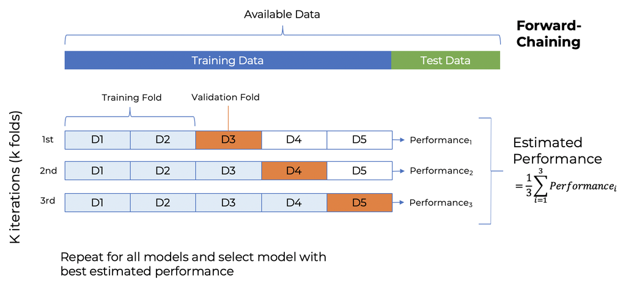

```python
Image("img/forward_chaining.png")
```

## Example: Linear Regression

### (Traditional) Train-Test

1. Fit all candidate models on training data (generally ~75% of the data)
2. Compute $RSE$, $R_{adj}^2$, $AIC$, $BIC$, or $C_p$ (just pick one! these are all metrics that penalize how many predictors are used) for all models on the training data
3. Select the model with the best performance measure
4. Run the selected model on the test data and assess the MSE

### Train-Validation-Test

1. Fit different linear models on 2/3 of the training data (generally ~75% of the data is training data, so this would be 50% of the total data)
2. Compute MSE of each model on the remaining part of the training data (the validation data, 25% of total data)
3. Select model with lowest MSE
4. Retrain the selected model on the entire training dataset (75% of total data)
5. Run the selected model on the test data (last 25%) and assess the MSE

We can use MSE instead of something like $RSE$ or $R_{adj}^2$ because everything is being assessed **out-of-sample.**

### k-Fold Cross Validation

1. Randomly divide the data into k folds (parts) of equal size. Best practice is $k=5$ or $k=10$.
2. For each candidate model:
   1. For each fold $j=1,...k$
      1. Fit the model on all the training data, excluding fold $j$
      2. Compute the $MSE$ of the fitted model on fold $j$ and call it $MSE_j$
   2. Estimate the perforamnce of the model by taking the average of all $MSE_j$ -- i.e. $MSE=\frac{1}{k}\sum_{j=1}^{k}MSE_j$
3. Select model with lowest $MSE$
4. Retrain the selected model on the entire training dataset
5. Assess $MSE$ of the final model on the test data

## Resources

[More advanced look at model selection and assessment](https://rafalab.github.io/pages/649/section-07.pdf)